# R Notebook

### Import Libraries

```r
install.packages("astsa")
library(astsa)
install.packages("forecast")
library(forecast)
install.packages("tidyverse", dependencies = TRUE)
library(tidyverse)
```

## Askisi 5:

the daily USD/CAD exchange rates for the last 2 years

1.Plot the time series

2. Βρείτε την ευθεία της τάσης με γραμμική παλινδρόμηση Και κάντε το κοινό γράφημα
3. Βρείτε quadratic trend και κάντε πάλι το γράφημα
4. Υπολογίστε τις πρώτες και δεύτερες διαφορές και κάντε τα αντίστοιχα γραφήματα
5. Κάντε μία πρόβλεψη με ένα από τα παραπάνω μοντέλα (4) για τις επόμενες 22 μέρες.
6. Προσθέστε μία εποχική συνιστώσα (π.χ. την επίδραση του Ιανουαρίου) στην γραμμική τάση (φτιάξτε μία binary μεταβλητή που θα δείχνει αν το exchange rate είναι από το Γενάρη ή όχι) Κάντε fit το μοντέλο με την επίδραση του Γενάρη.

(hint : χρησιμοποιείστε τη συνάρτηση format to convert the dates to strings)

7. Κάνετε fit a quadratic trend θεωρώντας και την επίδραση του Γενάρη
8. Κανετε το γράφημα διασποράς μεταξύ των τιμών exchange rates and the lagged values
9. Υπολογίστε την αυτοσυσχέτιση r_1 υστέρησης 1. Τι παρατηρείτε?
10. Φτιάξτε μια συνάρτηση (ονομάστε την cal AC(y,k) που θα υπολογίζει την αυτοσυσχέτιση υστέρισης k γενικά για μία χρονοσειρά
11. Στα παραπάνω δεδομένα φτιάξτε το ΑR(1) και MA(1) μοντέλο ΑR(1)=ARIMA(1,0,0) MA(1)=ARIMA(0,0,1)

### Bima 1:

Load the dataset that we fetched form www.bankofcanada.ca in to csv file seperated by ‘;’ and select the column FXUSDCAD that contains the values that we are interested in.

```r
path = "/Users/thanoskottaridis/Documents/metaptixiako_files/main lectures/b_eksamino/predictive_analytics/Apalaktiki Ergasia/final_project/Ask6_dataset.csv"
#x = read.csv(path,header=TRUE)
data = read.table(path, sep=";",dec=".",header=TRUE)
```

### Bima 2:

Pragmatopoioume elenxo ton dedomenon gia tin kaliteri katanoisi tous: - Elenxoume an ta data einai xronoseira. - Provaloume tin xronoseira (Erwtima 1 tis askisis) - Ipologizoume ta ACF kai PACF

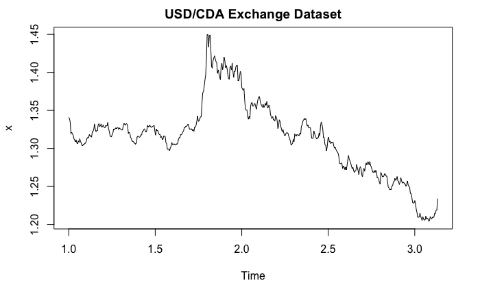

```r
x=ts(data$FXUSDCAD, frequency=235)

# plot cmort data
plot.ts(x, main="USD/CDA Exchange Dataset")
```

```r
x
```

[output not shown]

Βρείτε την ευθεία της τάσης με γραμμική παλινδρόμηση Και κάντε το κοινό γράφημα

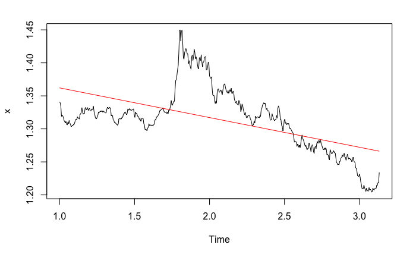

```r
time = time(x)
reg0 <- lm(x~time)
plot(x)
points(time,predict.lm(reg0),type='l',col='red')
```

# Quadratic trend

3. Βρείτε quadratic trend και κάντε πάλι το γράφημα

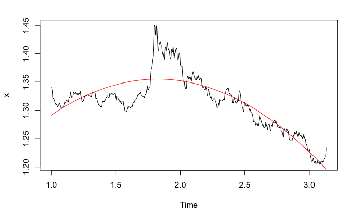

```r
reg1 <- lm(x~time + I(time^2))
plot(x)
points(time,predict.lm(reg1),type='l',col='red')
```

4. Υπολογίστε τις πρώτες και δεύτερες διαφορές και κάντε τα αντίστοιχα γραφήματα

```r
# Protes diafores
diff1<-diff(x,1)
plot.ts(diff1, main = "First Diffs Plot")

#Defteres diafores
diff2<-diff(x,2)
plot.ts(diff2, main = "Second Diffs Plot")
```

[output not shown]

22. να βρεθεί η πρόβλεψη και το 95% Διάστημα πρόβλεψης για 22 μέρες χρησιμοποιώντας το μοντέλο τυχαίου περίπατου. Στο γράφημα πρέπει αν φαίνονται και το άνω και κάτω φράγμα του διαστήματος πρόβλεψης (υπόδειξη : Στο άξονα y χρησιμοποιείστε μεγάλο εύρος διαφορετικά τα φράγματα του διαστήματος πρόβλεψης δεν θα φαίνονται στο σχήμα. Στο άξονα x είναι η μέρα (1-22)

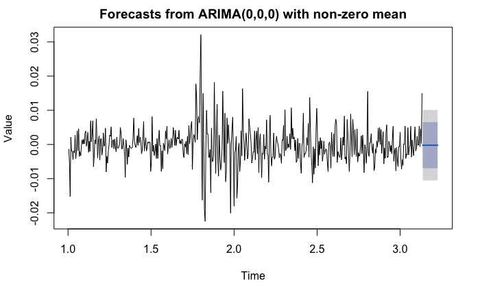

```r
for_diff1 <- forecast(diff1, h=22, model = arima(diff1, c(0,0,0)))
plot(for_diff1, ylab = 'Value', xlab = 'Time')
```

6. Προσθέστε μία εποχική συνιστώσα (π.χ. την επίδραση του Ιανουαρίου) στην γραμμική τάση (φτιάξτε μία binary μεταβλητή που θα δείχνει αν το exchange rate είναι από το Γενάρη ή όχι) Κάντε fit το μοντέλο με την επίδραση του Γενάρη.

**Epilisi** 1. na vrw olous tous jenuary apo ta arxika data 2. na eksalipsoume tin tasi pou mporei na exoun oi times tou ianouatiou 3. pernoume ton meso oro twn de-trend values tou ianouariou kai mas dinoun tin epoxiki sinistosa.

```r
# 1) kanw filter ola ta dates tou iannouariou apo ta arxika data.
jenData = dplyr::filter(data, grepl("-01-",date))
# 2) ta metatrepw se TS kai apalifw tin tasi
jenTS = ts(jenData$FXUSDCAD)
plot.ts(jenTS)
#  3) Paratiroume oti den iparxei tasi stis times tou ianouariou opote eksagoume tin epoxiki sinistosw pernontas ton meso oro
jen_season_factor = mean(jenTS)
print("Sesonal factor of jennuary is:")
jen_season_factor
```

[output not shown]

7. Κάνετε fit a quadratic trend θεωρώντας και την επίδραση του Γενάρη **Epilisi**

```r
temp <- replicate(length(time), jen_season_factor)
temp
reg2 <- lm(x~time + I(time^2))
#time
plot(x)
points(time,(predict.lm(reg2)+jen_season_factor)/2,type='l',col='red')
points(time,predict.lm(reg1),type='l',col='blue')
```

[output not shown]

8. Κανετε το γράφημα διασποράς μεταξύ των τιμών exchange rates and the lagged values

```r
lag1.plot(x,1)
```

[output not shown]

9. Υπολογίστε την αυτοσυσχέτιση r_1 υστέρησης 1. Τι παρατηρείτε?

```r
print(acf(x, lag.max = 2, plot = FALSE))
acf2(x,50)
```

[output not shown]

X. Φτιάξτε μια συνάρτηση (ονομάστε την cal AC(y,k) που θα υπολογίζει την αυτοσυσχέτιση υστέρισης k γενικά για μία χρονοσειρά

```r
AC <- function(y,k) {
  myACF <- acf(x, lag.max = k, plot = FALSE)
  return(unlist(myACF$acf)[k+1])
}

test <- AC(x,2)
test
```

[output not shown]

Στα παραπάνω δεδομένα φτιάξτε το ΑR(1) και MA(1) μοντέλο

```r
ts.plot(x)
acf2(x,50)
sarima(x,1,0,0)
sarima(x,0,0,1)
sarima(x,2,1,2)
```

[output not shown]

**Elenxos MAE, msem mape**

```r
for1 <- sarima.for(x[1:length(x-20)],20,1,0,0)
for2 <- sarima.for(x[1:length(x-20)],20,0,0,1)
for3 <- sarima.for(x[1:length(x-20)],20,2,1,2)
```

[output not shown]

```r
print("Model 1 evaluation")
acc1 <- accuracy(for1$pred,x[length(x-20):length(x)])
acc1
print("Model 2 evaluation")
acc2 <- accuracy(for2$pred,x[length(x-20):length(x)])
acc2
print("Model 3 evaluation")
acc3 <- accuracy(for3$pred,x[length(x-20):length(x)])
acc3
```

[output not shown]

```r
# compare RMSE
if ( acc1[2] <= acc2[2] & acc1[2] <= acc3[2] ) {
print("Best Model Is: Model 1")
} else if ( acc2[2] <= acc1[2] & acc2[2] <= acc3[2] ) {
print("Best Model Is: Model 2")
} else {
print("Best Model Is: Model 3")
}
```

[output not shown]